# p8105_hw1_xx2485.Rmd

Xiaoni Xu

2024-09-12

## Problem 1

Downloading a package containing the penguins dataset:

```r
# install.packages("palmerpenguins")
data("penguins", package = "palmerpenguins")
library(tidyverse)
```

```r
library(ggplot2)
```

A short description of the penguins dataset: In ‘penguins’ dataset, there are both qualitative and quantitative data about each individual penguin. The qualitative data includes species, location, sex, and year, while the quantitative data includes bill length, bill depth, flipper length, and body mass.

The size of the dataset can be found using the code below, which shows that there are 344 individuals with 8 categories of data.

```r
nrow(penguins)
```

```
## [1] 344
```

```r
ncol(penguins)
```

```
## [1] 8
```

The mean flipper length can be found using the code, which is 200.9152 mm after removing NA values.

```r
# clean the data first for the flipper length
penguins_filtered <- penguins %>%
  filter(!is.na(flipper_length_mm))

mean(penguins_filtered$flipper_length_mm)
```

```
## [1] 200.9152
```

Creating a scatterplot of flipper_length_mm (y) vs bill_length_mm (x):

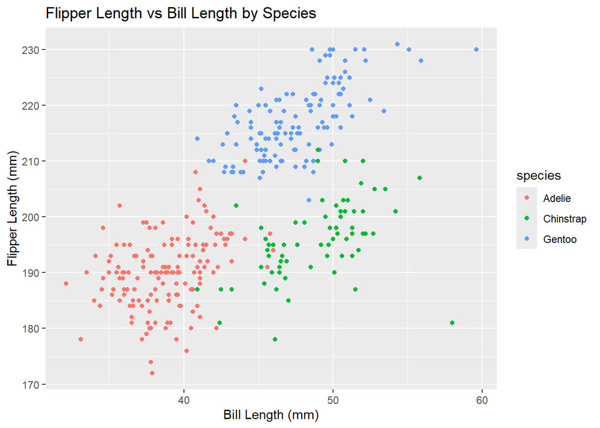

```r
penguins_filtered <- penguins %>%
  filter(!is.na(flipper_length_mm) & !is.na(bill_length_mm))

# Create the scatterplot
scatterplot <- ggplot(data = penguins_filtered, aes(x = bill_length_mm, y = flipper_length_mm, color = species)) +
  geom_point() +
  labs(title = "Flipper Length vs Bill Length by Species",
       x = "Bill Length (mm)",
       y = "Flipper Length (mm)")

# Display the plot
print(scatterplot)
```

```r
# Export the plot to the project directory
ggsave("scatterplot_flipper_vs_bill.png", plot = scatterplot, width = 7, height = 5)
```

## Problem 2

Creating a data frame comprised of: a random sample of size 10 from a standard Normal distribution a logical vector indicating whether elements of the sample are greater than 0 a character vector of length 10 a factor vector of length 10, with 3 different factor “levels”

```r
df =
  tibble(
    ran_samp = rnorm(n = 10),
    log_vec = ran_samp > 0,
    cha_vec = c("Calidris_canutus", "Calidris_pusilla", "Calidris_himantopus", "Calidris_subruficollis", "Calidris_alba", "Calidris alpina", "Calidris_maritima", "Calidris_bairdii", "Calidris_fuscicollis", "Calidris minutilla"),
    fac_vec = factor(c("rare", "common", "uncommon", "rare", "common", "uncommon", "rare", "rare", "rare", "common"), levels = c("common", "uncommon", "rare"))
  )
# the factor vector shows how common each Calidris species (sandpipers) is in Cook County, Illinois. Data source: my personal birding experience from 2019 to 2024 in Chicago
# the numeric values don't really have real meanings

print(df)
```

```
## # A tibble: 10 × 4
##    ran_samp log_vec cha_vec                fac_vec
##       <dbl> <lgl>   <chr>                  <fct>
##  1  -0.0513 FALSE   Calidris_canutus       rare
##  2   0.109  TRUE    Calidris_pusilla       common
##  3   1.39   TRUE    Calidris_himantopus    uncommon
##  4  -0.249  FALSE   Calidris_subruficollis rare
##  5   1.03   TRUE    Calidris_alba          common
##  6  -0.178  FALSE   Calidris alpina        uncommon
##  7   1.32   TRUE    Calidris_maritima      rare
##  8   0.678  TRUE    Calidris_bairdii       rare
##  9  -0.533  FALSE   Calidris_fuscicollis   rare
## 10  -2.18   FALSE   Calidris minutilla     common
```

Taking the mean of each variable in your dataframe.

```r
mean(df$ran_samp)
```

```
## [1] 0.1340465
```

```r
mean(df$log_vec)
```

```
## [1] 0.5
```

```r
mean(df$cha_vec)
```

```
## [1] NA
```

```r
mean(df$fac_vec)
```

```
## [1] NA
```

We can take the mean for the random sample of size 10 from a standard Normal distribution and the logical vector indicating whether elements of the sample are greater than 0, but we can’t take the mean for the character vector of length 10 or the factor vector of length 10.

Applying the as.numeric function to the logical, character, and factor variables:

```r
df$log_vec_numeric <- as.numeric(df$log_vec)
df$cha_vec_numeric <- as.numeric(df$cha_vec)
df$fac_vec_numeric <- as.numeric(df$fac_vec)
```

**What happens, and why?**

Logical variable (log_vec): When applying as.numeric(), TRUE is converted to 1 and FALSE is converted to 0. Logical values are internally considered as binary in R.

Character variable (cha_vec): as.numeric() cannot convert character factors into numbers directly, so it will return NA for each element of the vector.

Factor variable (fac_vec): When applying as.numeric(), it converts the factor levels into the numeric codes. The numeric code corresponds to the order of the levels. In this case, “common” = 1, “uncommon” = 2, and “rare” = 3.

**Why does this matter for taking the mean?**

For logical and factor variables, as.numeric() gives actual numeric values, so you could still calculate a mean. The mean of a logical vector would give the proportion of TRUE values, and the mean of a factor variable would give you a meaningless average of the numeric codes representing the levels of rarity in this case.